# Huehuetenangensis marker union: alone, with parviglumis, or with mexicana

chr10 GENOTYPE runs A (huehuetenangensis alone), B (+ parviglumis), C (+ mexicana); 2026-10-16

Author

Fausto Rodríguez-Zapata

Published

October 16, 2026

## Why

User, 2026-10-16: whether *Z. mays* ssp. *huehuetenangensis* (2 donors, 9 BC1 pools, 61 BC2S3 samples) gets its own union or joins another taxon’s (“we need data to have a decision”). Chen et al. (2022) Fig. 2a source data: F<sub>ST</sub> huehuetenangensis–parviglumis 0.200, –mexicana 0.248, –maize 0.330; mexicana–parviglumis 0.068. Run plan: `docs/runs/genotype_huehue_chr10.md`. Inputs (not in git): four small tables in `huehue_union/`, made by `agent/huehue_chr10/collect.sh` and `combine_inputs.R`; master copy in `` /rsstu/users/r/rrellan/BZea/ZEAL/genotype/notebook_inputs/``huehue_union/ ``; copy it next to this notebook to re-render.

## 1. Markers per donor

A donor’s RTIGER markers are the union sites gap filling calls ALT for it: its own tier-A sites plus gap-filled sites from the other donors of the same union (Milestone 9a).

| union | donor | union sites | tier-A sites | markers (union-ALT) | own | gap-filled |
| --- | --- | --- | --- | --- | --- | --- |
| alone | Zh.0020_P3 | 68,177 | 33,744 | 51,810 | 30,810 | 21,000 |
| alone | Zh.0030_P4 | 68,177 | 43,648 | 55,964 | 40,292 | 15,672 |
| + parviglumis | Zh.0020_P3 | 464,813 | 33,744 | 124,963 | 26,779 | 98,184 |
| + parviglumis | Zh.0030_P4 | 464,813 | 43,648 | 140,991 | 36,975 | 104,016 |
| + mexicana | Zh.0020_P3 | 410,196 | 33,744 | 112,116 | 26,851 | 85,265 |
| + mexicana | Zh.0030_P4 | 410,196 | 43,648 | 127,485 | 36,997 | 90,488 |

## 2. Calls: the sample introgression dosage check

Per donor, medians over its BC2S3 samples: donor segments per sample and ALT % of reads in REF / HET / ALT segments. A family has balanced tissue pools when the medians pass (at most 4 segments; REF <= 3 %, HET 30-55 %, ALT >= 75 %).

| donor | union | samples | segments, median | segments, max | REF % ALT | HET % ALT | ALT % ALT | tissue pools |
| --- | --- | --- | --- | --- | --- | --- | --- | --- |
| Zh.0020_P3 | alone | 26 | 1.5 | 25 | 1.9 | 37.6 | 75.5 | balanced |
| Zh.0020_P3 | + parviglumis | 26 | 1.0 | 7 | 1.6 | 38.4 | 82.9 | balanced |
| Zh.0020_P3 | + mexicana | 26 | 1.0 | 8 | 1.6 | 39.0 | 82.9 | balanced |
| Zh.0030_P4 | alone | 35 | 0.0 | 2 | 1.7 | 50.9 | 84.6 | balanced |
| Zh.0030_P4 | + parviglumis | 35 | 0.0 | 2 | 1.1 | 52.9 | 84.0 | balanced |
| Zh.0030_P4 | + mexicana | 35 | 0.0 | 2 | 1.1 | 52.8 | 84.4 | balanced |

## 3. Genotype classes

Share of chr10 called HET and donor per BC2S3 sample, against the single-locus BC2S2 expectation (HET 6.25 %, donor 9.4 %) and the SNP50K calls of the same samples.

| donor | calls | samples | HET % of chr10 | donor % of chr10 |
| --- | --- | --- | --- | --- |
| Zh.0020_P3 | SNP50K | 26 | 10.7 | 0.1 |
| Zh.0020_P3 | union + mexicana | 26 | 4.7 | 6.8 |
| Zh.0020_P3 | union + parviglumis | 26 | 4.6 | 6.9 |
| Zh.0020_P3 | union alone | 26 | 5.6 | 7.1 |
| Zh.0030_P4 | SNP50K | 35 | 4.1 | 0.0 |
| Zh.0030_P4 | union + mexicana | 35 | 4.7 | 0.3 |
| Zh.0030_P4 | union + parviglumis | 35 | 4.7 | 0.3 |
| Zh.0030_P4 | union alone | 35 | 3.4 | 1.6 |

## 4. What adding huehuetenangensis does to the partner taxon

Mexicana donors’ line-check medians, run C against run 1273053 (mexicana alone)

| donors | segments: changed donors | HET % ALT: max change | ALT % ALT: max change |
| --- | --- | --- | --- |
| 42 | 3 | 12.6 | 19.7 |

Run B is the first parviglumis run, so it has no parviglumis-only baseline to compare with.

## 5. Chromosome painting: SNP50K, the union alone and the union with parviglumis

One row per BC2S3 sample, grouped by donor; chr10 along the x axis. Left: SNP50K calls (RTIGER on the 50K panel); middle: RTIGER at the union-ALT markers of the huehuetenangensis-only union (run A); right: the union with the 40 parviglumis donors (run B).

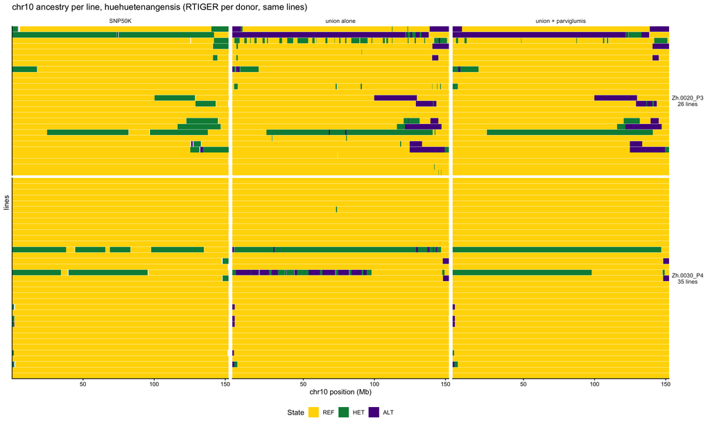

## 6. Notes (2026-10-16)

Pairwise F<sub>ST</sub> between the ZEAL taxa (Chen et al. 2022, Fig. 2a source data, five samples per taxon): parviglumis is the nearest taxon to every other one (huehuetenangensis 0.200, diploperennis 0.230, luxurians 0.235, mexicana 0.068); diploperennis and luxurians are far from each other (0.453) and from huehuetenangensis (0.48). Next: the same test for diploperennis (`docs/runs/genotype_diploperennis_partners_chr10.md`).